# Case Study I Unit 6, Doing Data Science

MessaA

June 22, 2016

# 1. Introduction

### The case study is produced using Rmarkdown codes, outputs including plots and tables to answer the following five questions.

### 1. After merging the two data by country short code, how many IDs matched?

### 2. What is the 13th country after ordering the countries in descending order?

### 3. What are the average GDP rankings for high income OECD and nonOECD?

### 4. Plot the GDP for all countries across income

### 5. Cut the GDP rankings in to 5 separate quantiles and make a table versus income

### The case study is also designed to be read in GitHub.

# 2. Analysis

### * libraries Requaired

### * library(repmis)

### * library(RCurl)

### * library(bitops)

### * library(plyr)

### * library(ggplot2)

### * library(reshape2)

## Quesition1. Match the data based on the country shortcode. How many of the IDs match?

```r
library(repmis)
library(RCurl)
```

```r
library(bitops)
gdpURL <- "https://d396qusza40orc.cloudfront.net/getdata%2Fdata%2FGDP.csv"
eduURL <- "https://d396qusza40orc.cloudfront.net/getdata%2Fdata%2FEDSTATS_Country.csv"
gdpFile <- tempfile()
eduFile <- tempfile()

download.file(gdpURL, gdpFile)
download.file(eduURL, eduFile)
```

### Read 190 ranked countries

```r
gdpData <- read.csv(gdpFile, skip = 5, nrows = 190, stringsAsFactors = F, header = F)
eduData <- read.csv(eduFile, stringsAsFactors = F)
```

### Subset only needed data, name columns in gdpData and convert GDP Value to numeric

```r
gdpData <- gdpData[, c(1, 2, 4, 5)]
colnames(gdpData) <- c("CountryCode", "Rank", "Country.Name", "GDP.Value")
gdpData$GDP.Value <- as.numeric(gsub(",", "", gdpData$GDP.Value))
```

### Merge data by country shortcodes

```r
matchedData <- merge(gdpData, eduData, by.x = "CountryCode", by.y = "CountryCode")
```

### Checking if there are missing values

```r
sum(is.na(matchedData))
```

```
## [1] 454
```

### Number of matched countries

```r
dim(matchedData)
```

```
## [1] 189  34
```

### The number of matched IDs in the data frame are [1] 189.

## Quesition 2.Sort the data frame in decending order by GDP rank (so United States is last). What is the 13th country in the resulting data frame?

### Arrange by GDP rank (descending order ) and get the name of the 13th country

```r
library(plyr)
arrange(matchedData, desc(Rank))[13, 3]
```

```
## [1] "St. Kitts and Nevis"
```

### The 13th country in the resulting data frame is “St. Kitts and Nevis”.

## Quesition 3. What are the average GDP rankings for the “High income: OECD” and “High income: nonOECD” groups?

### Subset “High income: OECD” and calculate the mean GDP Rank

```r
mean(subset(matchedData, Income.Group %in% "High income: OECD", select = c(Rank))$Rank)
```

```
## [1] 32.96667
```

### Subset “High income: nonOECD”

```r
mean(subset(matchedData, Income.Group %in% "High income: nonOECD", select = c(Rank))$Rank)
```

```
## [1] 91.91304
```

### The average GDP rankings for the“High income: OECD” and “High income: nonOECD” groups are 32.96667 and 91.91304 respectively.

## Quesition 4. Plot the GDP for all of the countries. Use ggplot2 to color your plot by Income Group

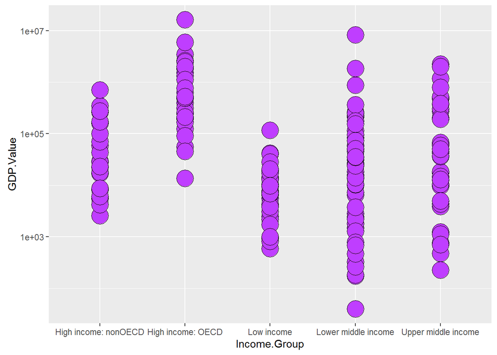

```r
library(ggplot2)
ggplot(matchedData,aes(y = GDP.Value, x =Income.Group)) + scale_y_log10()+ geom_point(pch = 21, size = 8, fill = I("darkorchid1"))
```

### The plot above shows the GDP distribution for all countries.

## Quesition 5. Cut the GDP ranking into 5 separate quantile groups. Make a table versus Income.Group. How many countries are Lower middle income but among the 38 nations with highest GDP?

### Cut the GDP ranking into 5 separate quantile groups

```r
breaks <- quantile(matchedData$Rank,seq(0, 1, 0.2))
head(cut(matchedData$Rank, breaks = breaks))
```

```
## [1] (152,190]   (76.2,114]  (38.6,76.2] (114,152]   (1,38.6]    (1,38.6]
## Levels: (1,38.6] (38.6,76.2] (76.2,114] (114,152] (152,190]
```

### Make a table of Income Groups across Rank Groups

```r
library(reshape2)
matchedData$quantile<-cut(matchedData$Rank,breaks=breaks)
table(matchedData$Income.Group, matchedData$quantile)
```

```
##
##                        (1,38.6] (38.6,76.2] (76.2,114] (114,152] (152,190]
##   High income: nonOECD        4           5          8         4         2
##   High income: OECD          17          10          1         1         0
##   Low income                  0           1          9        16        11
##   Lower middle income         5          13         11         9        16
##   Upper middle income        11           9          8         8         9
```

# 3. Conclusion:

### The following conclusions are drawn:

### * R and R markdown are very handy software to produce a reproducible report.

### * As seen in question number 3, the average GDP ranking for “High income: OECD” is less than the average GDP ranking for “High income: nonOECD” groups

### * The plot in question 4 shows that the GDP for the lower middle income countries is highly varied extends from low to high GDPs, whereas the GDP for the high income OECD and nonOECD groups is very close to all groups.

### * Above all the data are all observational data with no causal interpretation